# Report

Author

Jeffrey Liang

## Introductoin

Patients who endure and survive critical illnesses can face long term complications that impact their physical capacity.

Rural areas are known to have lower health conditions, and worse healthcare access than in urban areas.

The goal of this study is to investigate if rurality and neighborhood deprivation are associated with worse cognitive, disability, and quality of life outcomes in ICU survivors.

## Method

### Data

And the follow-up data include RBANS, ADL, FAQ, and SF-36 scores. The RBANS is a brief cognitive assessment tool that measures cognitive function in five domains: immediate memory, visuospatial/constructional, language, attention, and delayed memory. The ADL and FAQ are disability assessment tools. The SF-36 is a quality of life assessment tool. We will use the RBANS global score as the primary outcome, and the ADL, FAQ, and SF-36 scores as secondary outcomes.

To represent the rurality, Rural-Urban Commuting Areas (RUCA) codes were used. The RUCA codes are a classification scheme that distinguishes metropolitan and non-metropolitan counties by the size of the urban population and the extent of commuting to larger urban areas. The RUCA codes were obtained from the 2000 Census data.

In addition, the Area Deprivation Index (ADI) was used to represent the neighborhood deprivation. The ADI is a composite measure of neighborhood socioeconomic disadvantage that is based on 17 variables from the US Census. The ADI was obtained from the 2010 Census data.

Other covariates include Age at enrollment, The Charlson Comorbidity Index measures the severity and number of comorbid conditions. Cognitive baselines are assessed using the IQCODE, which typically ranges from 1 (much improved) to 5 (much worse). Disability models employ the Baseline Katz Index, scoring from 0 (independent) to 6 (dependent), and the Functional Activities Questionnaire, with scores from 0 (normal) to 30 (severe dysfunction). The Mean Modified Daily SOFA quantifies organ failure severity. The dataset also records days of delirium or coma and days under mechanical ventilation. Educational levels are noted, without a specified range, reflecting the highest education completed. The sex variable classifies individuals typically into male or female. Lastly, the dataset distinguishes between VA (Veterans Affairs) and civilian hospitals, with records from VA patients identified starting from code 14001

### Missing Data

To handle missing data, multiple imputation techniques will be applied using the ‘mice’ package. Predictive mean matching will serve as the method for imputing missing values. This approach targets gaps in demographic, ICU electronic health records summaries, and follow-up data, assuming not all sub-scores are absent.

## Statistical Analysis

#### Build Cohort

- Filter subjects that discharge from hospitals
- Filter subjects that has at least 1 observation in 3 month or 12 months
- Filter subjects that has at least 1 RBANS observation in any categories

#### Consort Diagarm

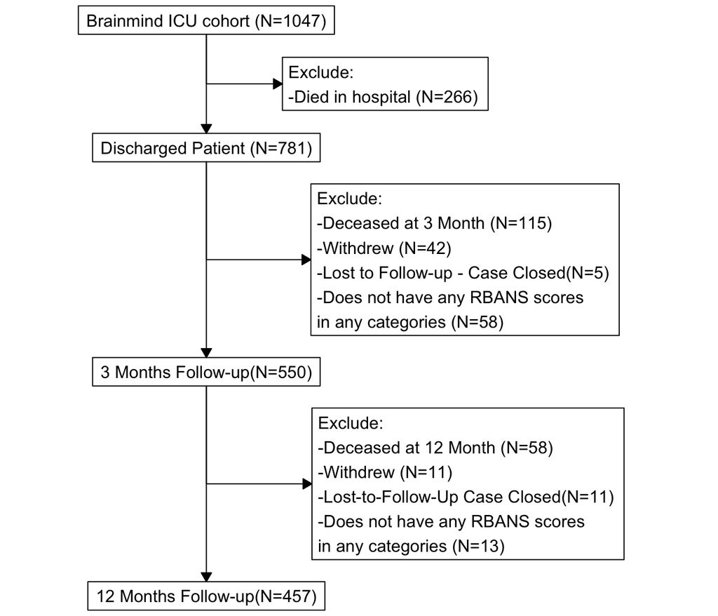

#### Descriptive Statistics

Table.1 Cohort Characteristics

|  | Overall (N=550) |
| --- | --- |
| **Age at enrollment** |  |
| meanIQR | 59.92 [51.37- 69.99] |
| **Sex** |  |
| Male | 327 (59.5%) |
| Female | 223 (40.5%) |
| **Years of education** |  |
| N-Miss | 4 |
| meanIQR | 12.64 [12.00- 14.00] |
| **IQCODE score at enrollment (missing -> 3)** |  |
| meanIQR | 3.11 [3.00- 3.12] |
| **FAQ category at enrollment** |  |
| N-Miss | 5 |
| No impairment | 502 (92.1%) |
| Functional impairment | 43 (7.9%) |
| **Katz ADL category at enrollment** |  |
| N-Miss | 19 |
| Independent | 466 (87.8%) |
| Partial disability | 56 (10.5%) |
| Total dependence | 9 (1.7%) |
| **Body Mass Index (BMI)** |  |
| N-Miss | 3 |
| meanIQR | 31.81 [24.96- 35.36] |
| **Charlson score** |  |
| meanIQR | 2.40 [1.00- 4.00] |
| **CSHA Frailty Index** |  |
| 1. Very fit | 21 (3.8%) |
| 2. Well | 90 (16.4%) |
| 3. Well with treated comorbid disease | 192 (34.9%) |
| 4. Apparently vulnerable | 120 (21.8%) |
| 5. Mildly frail | 68 (12.4%) |

[output cut: 57 more lines]

#### Descriptive of Outcome

Table.2 Descriptives of outcomes

|  | 3 Month (N=550) | 12 Month (N=457) | p value |
| --- | --- | --- | --- |
| **RBANS global composite score** |  |  | 0.084 |
| N-Miss | 86 | 60 |  |
| meanIQR | 79.25 [71.00- 87.00] | 80.83 [72.00- 90.00] |  |
| **Trails B t-score** |  |  | 0.004 |
| N-Miss | 70 | 55 |  |
| meanIQR | 39.99 [33.00- 48.00] | 42.46 [35.00- 50.00] |  |
| **ADL dependence category** |  |  | 0.020 |
| N-Miss | 27 | 8 |  |
| No dependence (score = 0) | 330 (63.1%) | 315 (70.2%) |  |
| Some dependence (score >=1) | 193 (36.9%) | 134 (29.8%) |  |
| **ADL total score** |  |  | 0.010 |
| N-Miss | 27 | 8 |  |
| meanIQR | 1.26 [0.00- 1.50] | 0.90 [0.00- 1.00] |  |
| **FAQ total score** |  |  | 0.089 |
| N-Miss | 32 | 10 |  |
| meanIQR | 5.69 [0.00- 9.00] | 4.98 [0.00- 8.00] |  |
| **FAQ impairment category** |  |  | 0.243 |
| N-Miss | 32 | 10 |  |
| No impairment (score 0-8) | 383 (73.9%) | 345 (77.2%) |  |
| Some impairment (score >=9) | 135 (26.1%) | 102 (22.8%) |  |
| **SF-36 physical component score** |  |  | < 0.001 |
| N-Miss | 35 | 18 |  |
| meanIQR | 30.46 [22.07- 37.40] | 33.37 [24.41- 41.77] |  |
| **SF-36 mental component score** |  |  | 0.613 |
| N-Miss | 35 | 18 |  |
| meanIQR | 49.98 [39.72- 61.74] | 50.45 [41.74- 60.46] |  |
| **Status at followup** |  |  |  |
| Deceased | 0 (0.0%) | 0 (0.0%) |  |
| Living | 11 (2.0%) | 1 (0.2%) |  |
| Living-Active in the study | 524 (95.3%) | 456 (99.8%) |  |
| Living-Withdrew from the study | 0 (0.0%) | 0 (0.0%) |  |
| Lost to Follow-Up - Case Closed | 0 (0.0%) | 0 (0.0%) |  |
| Visit Not Completed | 13 (2.4%) | 0 (0.0%) |  |
| Still Trying to Contact | 2 (0.4%) | 0 (0.0%) |  |

## EDA

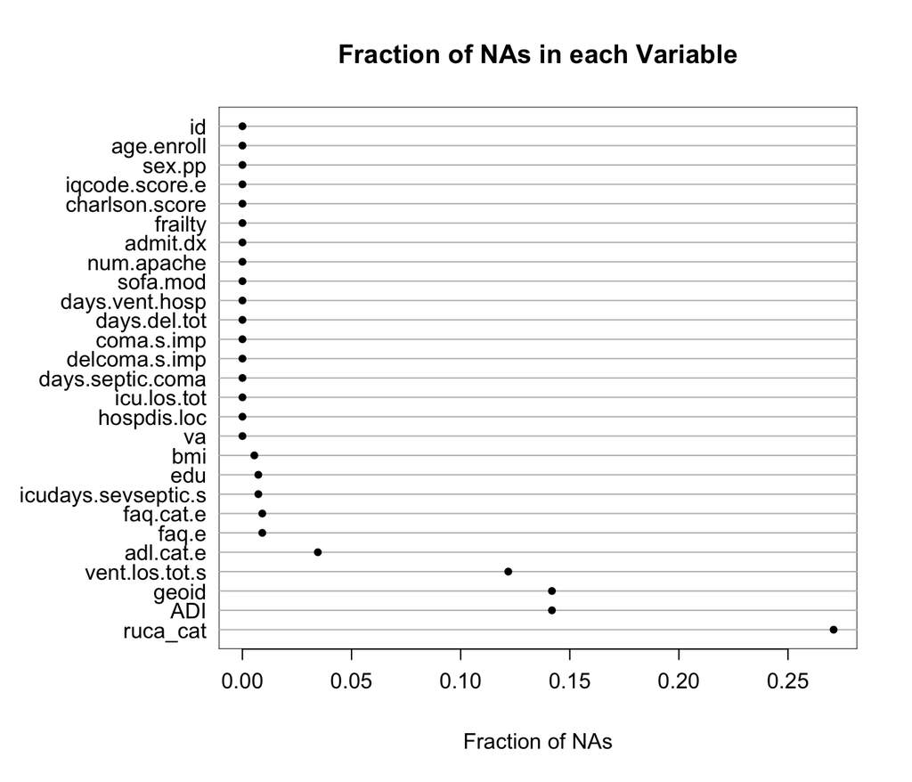

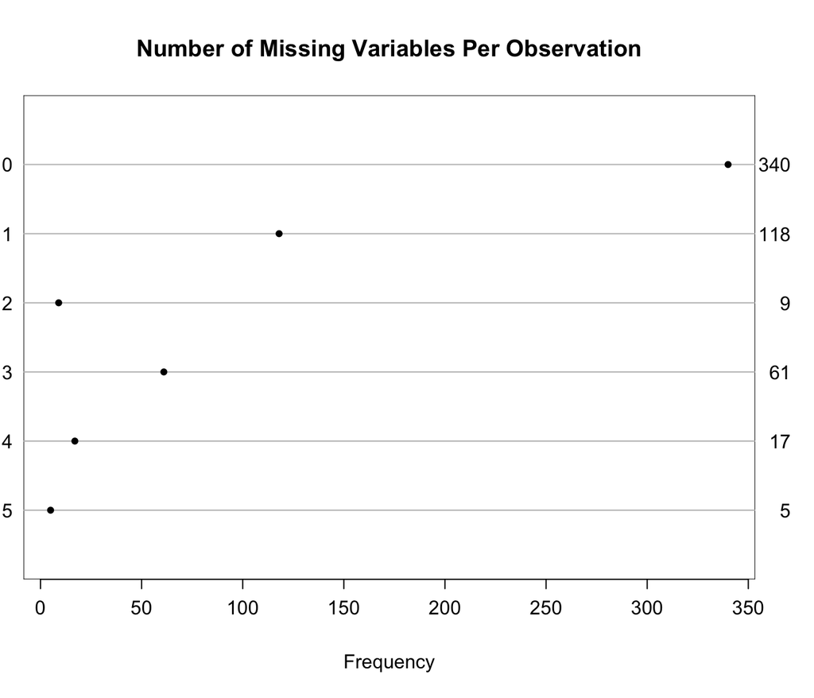

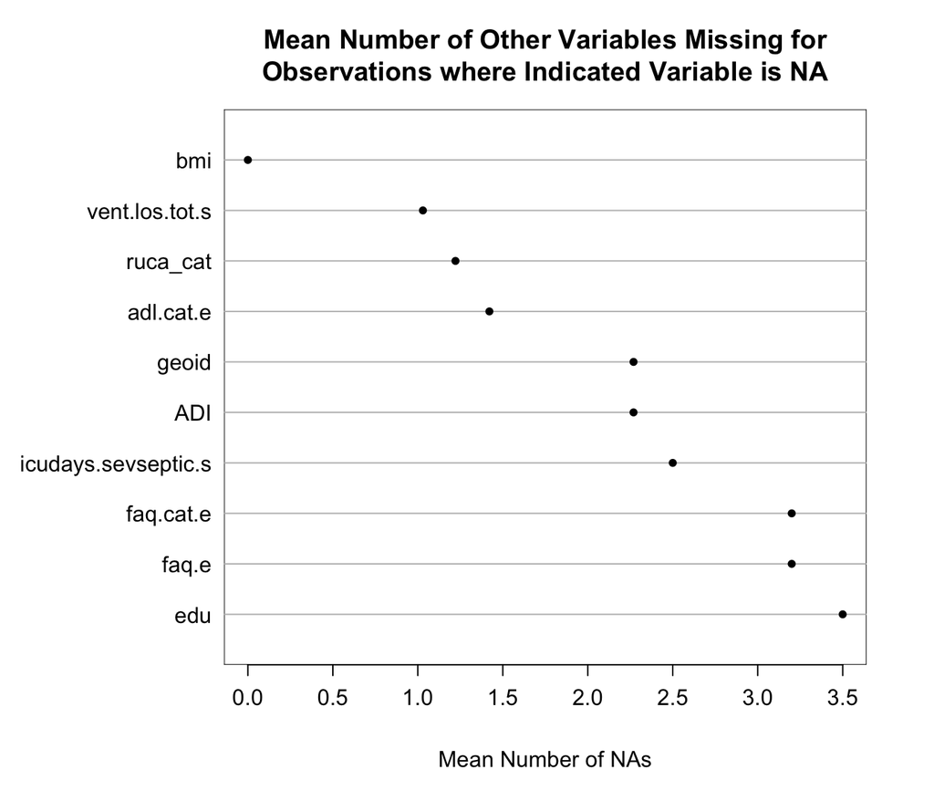

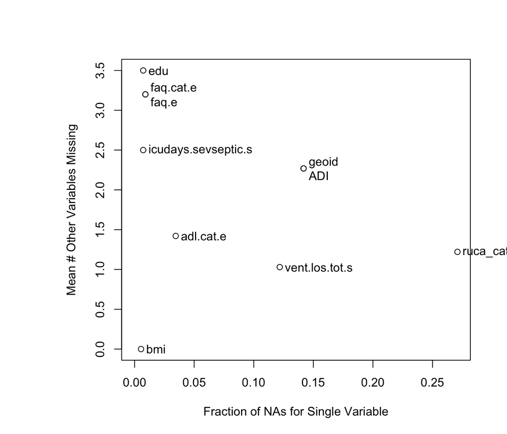

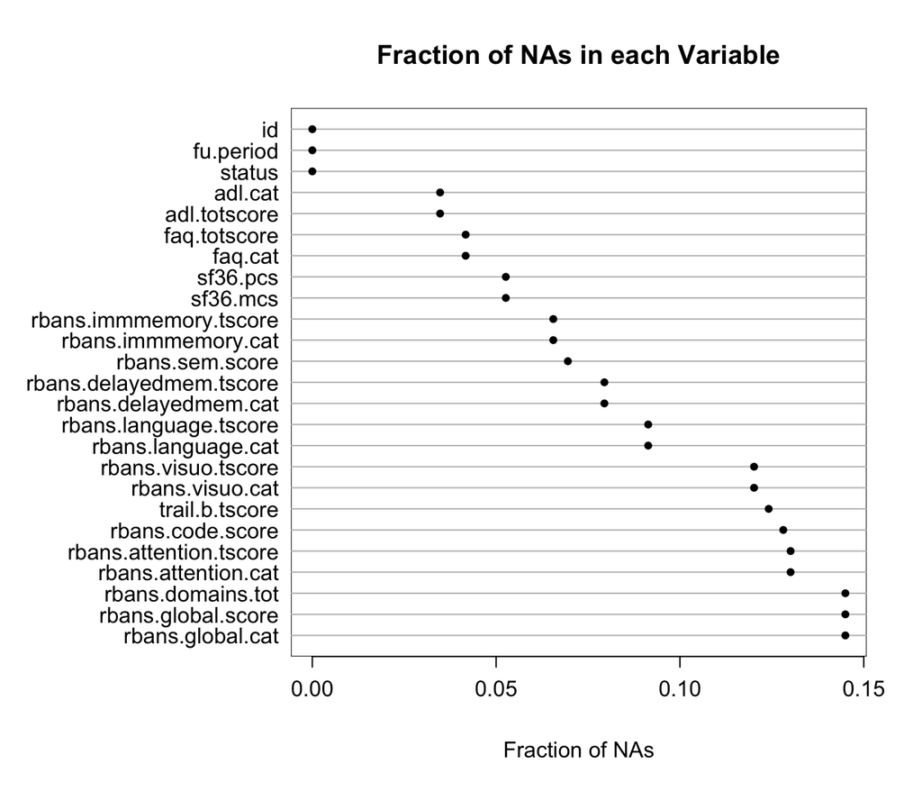

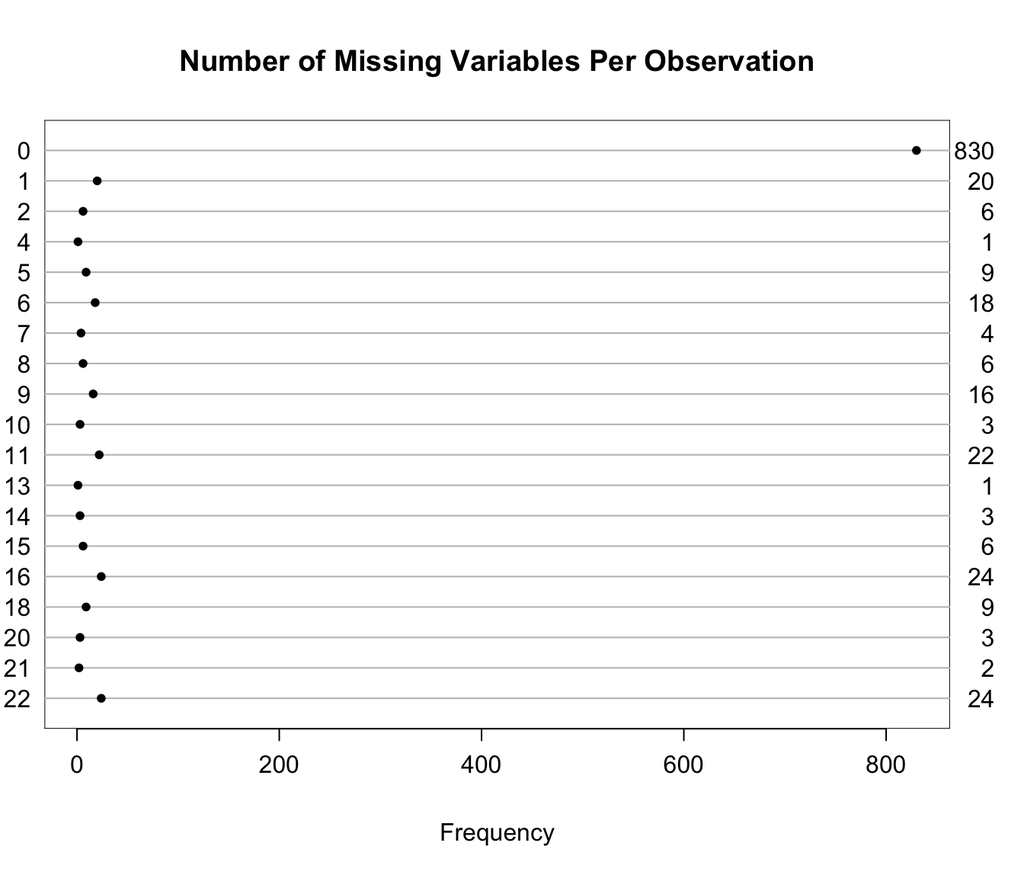

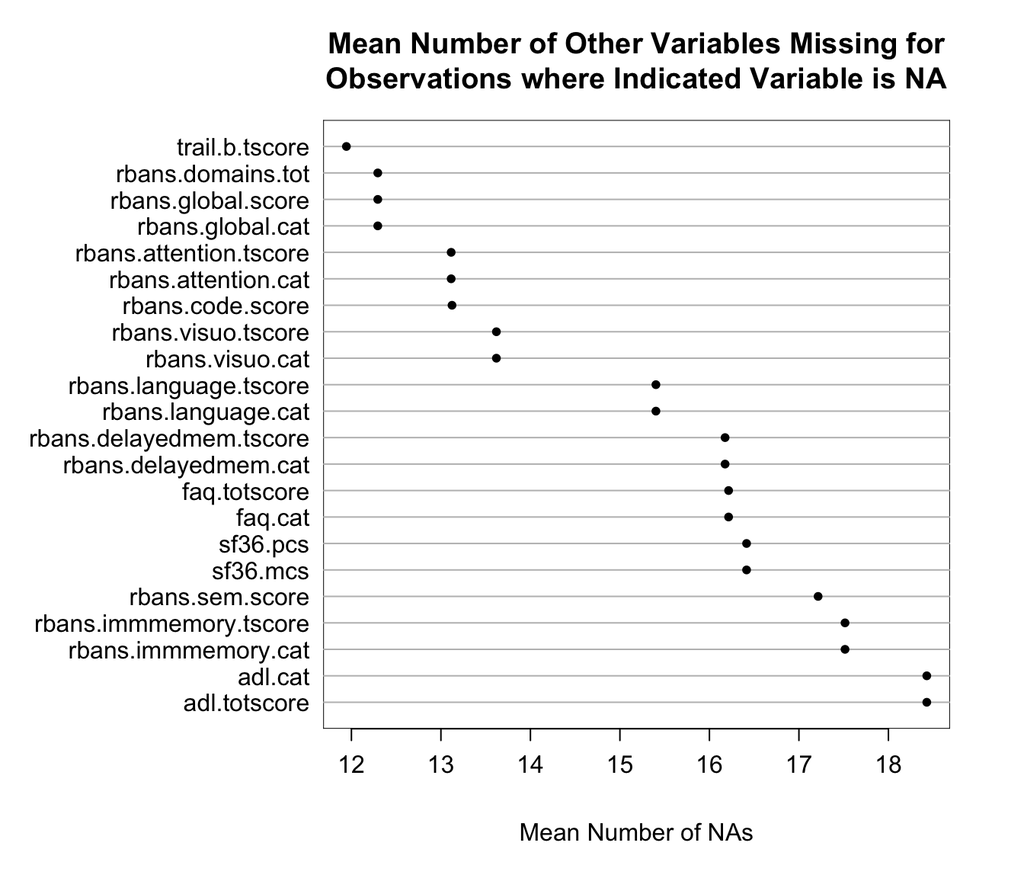

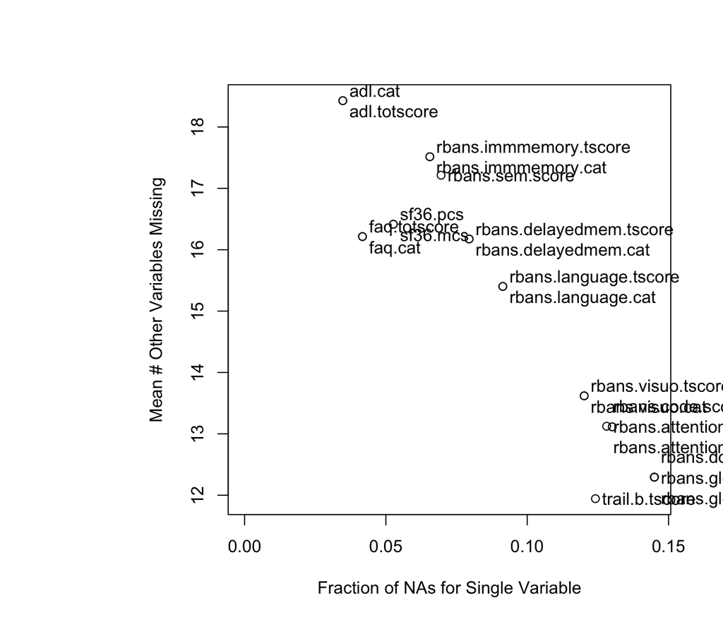

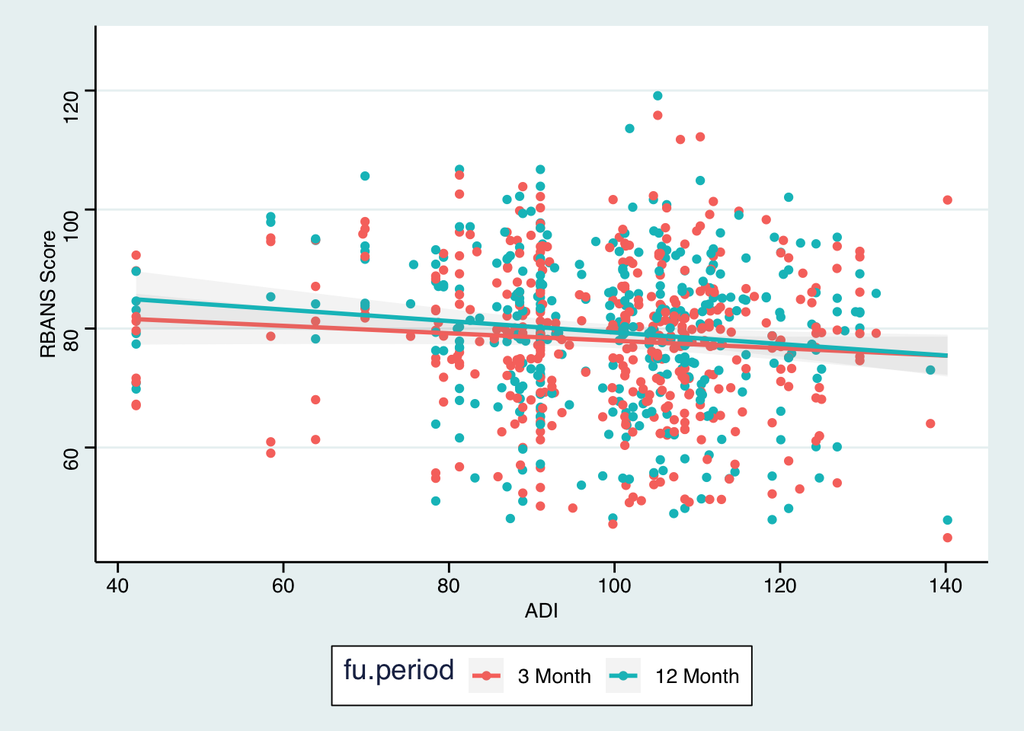

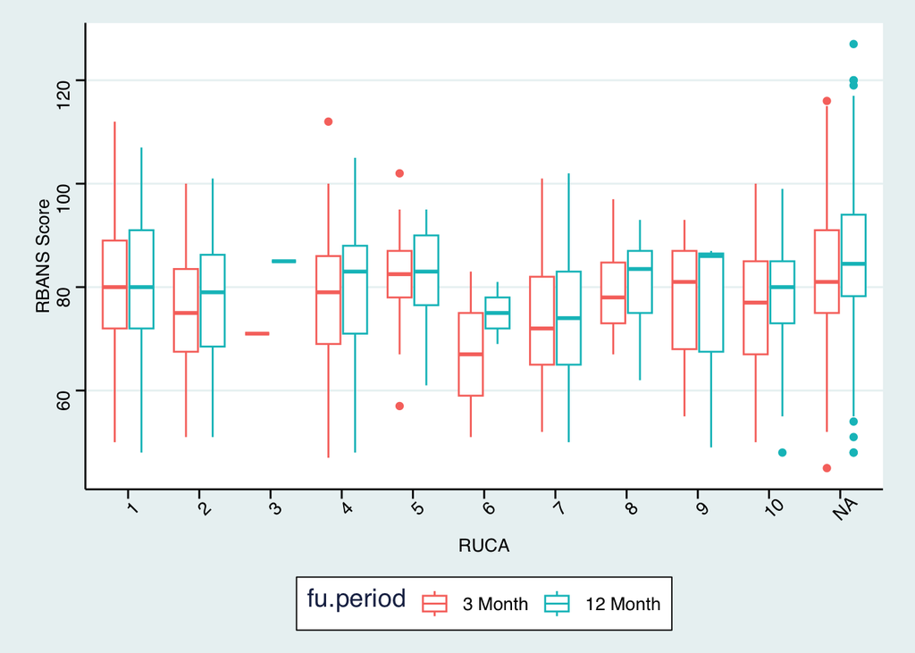

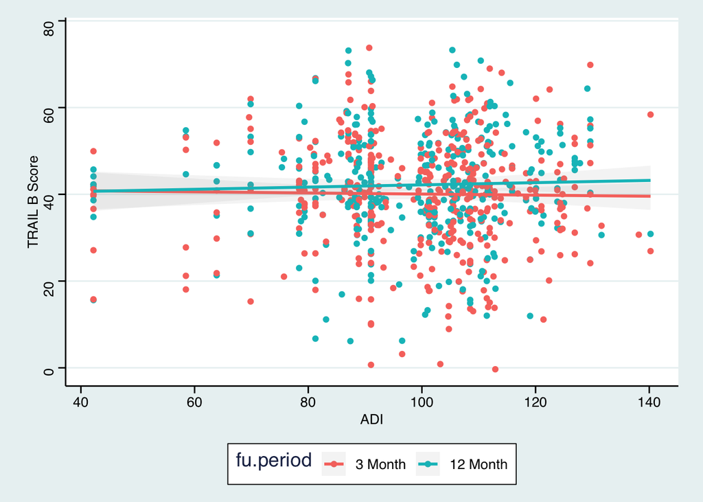

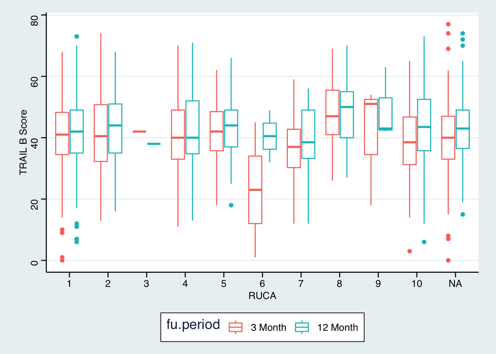

[2 more figures not shown]

```
# A tibble: 2 × 2
      n    nn
  <dbl> <int>
1     1    93
2     3   457
```

## Model

- Missing Data?(I dont mind imputing x, but imputing 3 months? thats depends)
- Interaction model or Longitudinal model

## Supplementary

|  | Overall (N=781) |
| --- | --- |
| **Age at enrollment** |  |
| meanIQR | 60.78 [52.24- 71.05] |
| **Sex** |  |
| Male | 463 (59.3%) |
| Female | 318 (40.7%) |
| **Years of education** |  |
| N-Miss | 9 |
| meanIQR | 12.40 [12.00- 14.00] |
| **IQCODE score at enrollment (missing -> 3)** |  |
| meanIQR | 3.12 [3.00- 3.12] |
| **FAQ category at enrollment** |  |
| N-Miss | 7 |
| No impairment | 703 (90.8%) |
| Functional impairment | 71 (9.2%) |
| **Katz ADL category at enrollment** |  |
| N-Miss | 34 |
| Independent | 636 (85.1%) |
| Partial disability | 87 (11.6%) |
| Total dependence | 24 (3.2%) |
| **Body Mass Index (BMI)** |  |
| N-Miss | 4 |
| meanIQR | 31.59 [24.71- 35.37] |
| **Charlson score** |  |
| meanIQR | 2.57 [1.00- 4.00] |
| **CSHA Frailty Index** |  |
| 1. Very fit | 27 (3.5%) |
| 2. Well | 110 (14.1%) |
| 3. Well with treated comorbid disease | 268 (34.3%) |
| 4. Apparently vulnerable | 166 (21.3%) |
| 5. Mildly frail | 99 (12.7%) |

[output cut: 57 more lines]